# Reproducibility Instructions

This report narrates data preparations for the Longitudinal Models of Religiosity in NLSY97

## Data Retrieval

Using [NLS Investigator](https://www.nlsinfo.org/investigator/pages/login.jsp) a list of variables was downloaded from [NLS](http://www.bls.gov/nls/) datasets. All the downloaded materials were unzipped into the folder “**/Documentation/data/NLSY97_Religiosity_20042014**”, located in the GitHub Repository. (The naming convention is “Study_Focus_DDMMYYYofDownload”)

#### The files include:

NLSY97_Religiosity_20042014.cdb - **codebook** containing item descriptions  
NLSY97_Religiosity_20042014.csv - **data** in comma delimited format  
NLSY97_Religiosity_20042014.NLSY97 - **tagset**, the list of variables in the downloaded dataset  
NLSY97_Religiosity_20042014.dtc - STATA® **dictionary** file of selected variables, contains data as well

After importing the data from the datafile,

[output not shown]

we have created the initial wide dataset with

```r
# dsSource  - cointains all imported variables
length(unique(dsSource$id))
```

[output not shown]

```r
# 1 - Cross-sectional
# 0 - Oversample
table(dsSource$sample)
```

```
< table of extent 0 >
```

```r
# dsSourceLabels - contains the RNUM (NLSY97 Variables codes) and VARIABLE_TITLE used by NLY Investigator
print(dsSourceLabels)
```

```
        RNUM                                VARIABLE_TITLE
1   R0323900              # DAYS/WK TYP FAM RELIGIOUS 1997
2   R2165200              # DAYS/WK TYP FAM RELIGIOUS 1998
3   R3483100              # DAYS/WK TYP FAM RELIGIOUS 1999
4   R4881300              # DAYS/WK TYP FAM RELIGIOUS 2000
5   S2977900 CURRENTLY HAVE ACCESS TO INTERNET? (SAQ) 2003
6   S4676700 CURRENTLY HAVE ACCESS TO INTERNET? (SAQ) 2004
7   S6308900 CURRENTLY HAVE ACCESS TO INTERNET? (SAQ) 2005
8   S8329800 CURRENTLY HAVE ACCESS TO INTERNET? (SAQ) 2006
9   T0737600 CURRENTLY HAVE ACCESS TO INTERNET? (SAQ) 2007
10  T2779700 CURRENTLY HAVE ACCESS TO INTERNET? (SAQ) 2008
11  T4494400 CURRENTLY HAVE ACCESS TO INTERNET? (SAQ) 2009
12  T6141400 CURRENTLY HAVE ACCESS TO INTERNET? (SAQ) 2010
13  T7635300 CURRENTLY HAVE ACCESS TO INTERNET? (SAQ) 2011
14  R1193900                  CV_AGE(MONTHS)_INT_DATE 1997
```

[output cut: 119 more lines]

To explore the variables in the native context of NLS, go to [NLS Investigator](https://www.nlsinfo.org/investigator/pages/login.jsp), select “NLYS97 1997-2011” in the first dropdown box and then click on “Choose File” under “Upload Tagset.” Select the file “NLSY97_Religiosity_20042014.NLSY97” from the folder “**/Documentation/data/NLSY97_Religiosity_20042014**”, in the GitHub repository.

## Variables by Occasions

To better understand the longitudinal structure of the selected variables, the dataset was re-arranged in the two-dimensional slice of Cattell's databox: variables by occasions.

## Figure 1

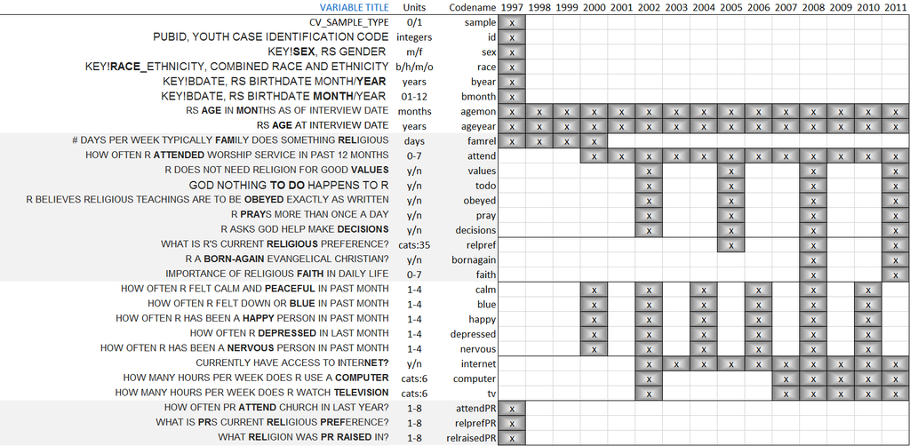

Interactive version

This databox slice indicates in what year measurement was taken for selected variables and describes the variables extracted from NLYS97 for analysis. Three descriptions are given:  
**Variable Title**, which is verbatim identifier from NLSY97,  
**Unit**, which attemps to give a brief desription of the scale on which the variable is measured, and  
**Codename**, which spells the name of the variable, as it is used in R code that services the analysis

The excel spreadsheet (*NLYS97_Religiosity_20042014.xlsx*) in the “./Documentation/data” folder, hosts this list, as well as a semi-automated routine (Tab “Renaming”) to aid in renaming the repeated endings in the variable names for easier coding. The values in the “Variable Title” can be used to locate the item in the [NLS Investigator](https://www.nlsinfo.org/investigator/pages/login.jsp) by copy/pasting it into “Word in Title” search line

## Figure 2

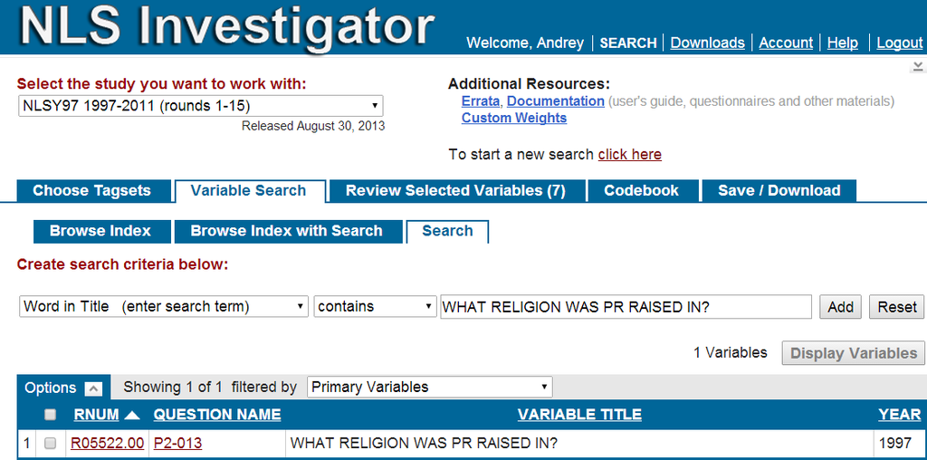

After renaming, we arrive at the basic clean dataset in wide format.

```r
# Using renaming template "NLSY97_Religiosity_20042014.xlsx" located in "Documentation\data" folder
# rename the native variable names of NLSY97 (left) into custom chosen names for programming convenience (right)

dsSource<-rename(dsSource, c(
  "R0323900"="famrel_1997",
  "R2165200"="famrel_1998",
  "R3483100"="famrel_1999",
  "R4881300"="famrel_2000",
  "S2977900"="internet_2003",
  "S4676700"="internet_2004",
  "S6308900"="internet_2005",
  "S8329800"="internet_2006",
  "T0737600"="internet_2007",
  "T2779700"="internet_2008",
  "T4494400"="internet_2009",
  "T6141400"="internet_2010",
  "T7635300"="internet_2011",
  "R1193900"="agemon_1997",
  "R2553400"="agemon_1998",
  "R3876200"="agemon_1999",
  "R5453600"="agemon_2000",
  "R7215900"="agemon_2001",
  "S1531300"="agemon_2002",
  "S2000900"="agemon_2003",
  "S3801000"="agemon_2004",
  "S5400900"="agemon_2005",
  "S7501100"="agemon_2006",
  "T0008400"="agemon_2007",
  "T2011000"="agemon_2008",
  "T3601400"="agemon_2009",
  "T5201300"="agemon_2010",
  "T6651200"="agemon_2011",
  "R1194100"="ageyear_1997",
  "R2553500"="ageyear_1998",
  "R3876300"="ageyear_1999",
  "R5453700"="ageyear_2000",
  "R7216000"="ageyear_2001",
  "S1531400"="ageyear_2002",
  "S2001000"="ageyear_2003",
  "S3801100"="ageyear_2004",
  "S5401000"="ageyear_2005",
  "S7501200"="ageyear_2006",
  "T0008500"="ageyear_2007",
  "T2011100"="ageyear_2008",
  "T3601500"="ageyear_2009",
  "T5201400"="ageyear_2010",
  "T6651300"="ageyear_2011",
  "R1235800"="sample",
  "S0919700"="todo_2002",
  "S6317100"="todo_2005",
  "T2782200"="todo_2008",
  "T7637800"="todo_2011",
  "R4893900"="happy_2000",
  "S0921100"="happy_2002",
  "S4682200"="happy_2004",
  "S8332600"="happy_2006",
  "T2782900"="happy_2008",
  "T6144000"="happy_2010",
  "R4893600"="nervous_2000",
  "S0920800"="nervous_2002",
  "S4681900"="nervous_2004",
  "S8332300"="nervous_2006",
  "T2782600"="nervous_2008",
  "T6143700"="nervous_2010",
  "R4893700"="calm_2000",
  "S0920900"="calm_2002",
  "S4682000"="calm_2004",
  "S8332400"="calm_2006",
  "T2782700"="calm_2008",
  "T6143800"="calm_2010",
  "R4894000"="depressed_2000",
  "S0921200"="depressed_2002",
  "S4682300"="depressed_2004",
  "S8332700"="depressed_2006",
  "T2783000"="depressed_2008",
  "T6144100"="depressed_2010",
  "R4893800"="blue_2000",
  "S0921000"="blue_2002",
  "S4682100"="blue_2004",
  "S8332500"="blue_2006",
  "T2782800"="blue_2008",
  "T6143900"="blue_2010",
  "R0552400"="attendPR",
  "R4893400"="attend_2000",
  "R6520100"="attend_2001",
  "S0919300"="attend_2002",
  "S2987800"="attend_2003",
  "S4681700"="attend_2004",
  "S6316700"="attend_2005",
  "S8331500"="attend_2006",
  "T0739400"="attend_2007",
  "T2781700"="attend_2008",
  "T4495000"="attend_2009",
  "T6143400"="attend_2010",
  "T7637300"="attend_2011",
  "S1225400"="computer_2002",
  "T1049900"="computer_2007",
  "T3145100"="computer_2008",
  "T4565400"="computer_2009",
  "T6209600"="computer_2010",
  "T7707000"="computer_2011",
  "S1225500"="tv_2002",
  "T1050000"="tv_2007",
  "T3145200"="tv_2008",
  "T4565500"="tv_2009",
  "T6209700"="tv_2010",
  "T7707100"="faith_2011",
  "T2782400"="faith_2008",
  "T7638000"="bmonth",
  "R0536401"="bmonth",
  "R0536402"="byear",
  "R1482600"="race",
  "R0536300"="sex",
  "R0000100"="id",
  "T2111500"="bornagain_2008",
  "T6759400"="bornagain_2011",
  "S0919600"="decisions_2002",
  "S6317000"="decisions_2005",
  "T2782100"="decisions_2008",
  "T7637700"="decisions_2011",
  "S0919500"="obeyed_2002",
  "S6316900"="obeyed_2005",
  "T2782000"="obeyed_2008",
  "T7637600"="obeyed_2011",
  "S5532800"="relpref_2005",
  "T2111400"="relpref_2008",
  "T6759300"="relpref_2011",
  "S0919400"="values_2002",
  "S6316800"="values_2005",
  "T2781900"="values_2008",
  "T7637500"="values_2011",
  "S0919800"="pray_2002",
  "S6317200"="pray_2005",
  "T2782300"="pray_2008",
  "T7637900"="pray_2011",
  "R0552300"="relprefPR",
  "R0552200"="relraisedPR"
))

# negativelyPhrased<-c("todo_","values_")
# negativelyYears<-c("2002","2005","2008","2011")
#
# for (i in negativelyPhrased){
#   for(k in negativelyYears){
# dsSource$paste0(i,k)=ifelse(( dsSource$paste0(i,k) %in% c(1)),0,ifelse(( dsSource$paste0(i,k) %in% c(0)),1,NA))
# }
# }
dsLong$year <- as.integer(dsLong$year) #Convert to a number.
```

[output not shown]

```r
# recode negativale worded question:  1 - more religious
dsSource$todo_2002=ifelse((dsSource$todo_2002 %in% c(1)),0,ifelse((dsSource$todo_2002 %in% c(0)),1,NA))
dsSource$todo_2005=ifelse((dsSource$todo_2005 %in% c(1)),0,ifelse((dsSource$todo_2005 %in% c(0)),1,NA))
dsSource$todo_2008=ifelse((dsSource$todo_2008 %in% c(1)),0,ifelse((dsSource$todo_2008 %in% c(0)),1,NA))
dsSource$todo_2011=ifelse((dsSource$todo_2011 %in% c(1)),0,ifelse((dsSource$todo_2011 %in% c(0)),1,NA))

dsSource$values_2002=ifelse((dsSource$values_2002 %in% c(1)),0,ifelse((dsSource$values_2002 %in% c(0)),1,NA))
dsSource$values_2005=ifelse((dsSource$values_2005 %in% c(1)),0,ifelse((dsSource$values_2005 %in% c(0)),1,NA))
dsSource$values_2008=ifelse((dsSource$values_2008 %in% c(1)),0,ifelse((dsSource$values_2008 %in% c(0)),1,NA))
dsSource$values_2011=ifelse((dsSource$values_2011 %in% c(1)),0,ifelse((dsSource$values_2011 %in% c(0)),1,NA))

# Include only records with a valid birth year
dsSource <- dsSource[dsSource$byear %in% 1980:1984, ]

#Include only records with a valid ID
dsSource <- dsSource[dsSource$id != "V", ]
dsSource$id <- as.integer(dsSource$id)
# remove all but one dataset
#  rm(list=setdiff(ls(), "dsSource"))

# Variables, which values that DON'T change with time - time invariant (TI) variables
TIvars<-c("sample", "id", "sex","race", "byear", "bmonth", 'attendPR', "relprefPR", "relraisedPR")

??str_sub


#################################
## Preparing the common Long dataset
ds<-dsSource
## id.vars declares MEASURED variables (as opposed to RESPONSE variable)
dsLong <- reshape2::melt(ds, id.vars=TIvars)
# create varaible "year" by stripping the automatic ending in TV variables' names
dsLong$year<-str_sub(dsLong$variable,-4,-1)
# the automatic ending in TV variables' names
timepattern<-c("_1997", "_1998", "_1999", "_2000", "_2001", "_2002", "_2003", "_2004", "_2005", "_2006","_2007", "_2008", "_2009", "_2010", "_2011")
# Strip off the automatic ending
for (i in timepattern){
dsLong$variable <- gsub(pattern=i, replacement="", x=dsLong$variable)
}
# Convert to a number.
dsLong$year <- as.integer(dsLong$year)
# Remove illegal values
illegal<-c(-5:-1,997,998,999)
dsLong$value=ifelse(dsLong$value %in% illegal,NA,dsLong$value)
# reorder for easier inspection
dsLong<-dsLong[with(dsLong, order(id,variable)), ]
# view the long data for one person
print(dsLong[dsLong$id==1,])

##############################
## Create individual long datasets, one per TV variable
TVvars<-unique(dsLong$variable)
TVvars<-"attend"

dsL_agemon<-subset(dsLong,subset=(dsLong$variable=="agemon"))
dsL_agemon<-rename(dsL_agemon,replace=c("value"="agemon"))
dsL_agemon$variable<-NULL

dsL_attend<-subset(dsLong,subset=(dsLong$variable=="attend"))
dsL_attend<-rename(dsL_attend,replace=c("value"="attend"))
dsL_attend$variable<-NULL

dsL_internet<-subset(dsLong,subset=(dsLong$variable=="internet"))
dsL_internet<-rename(dsL_internet,replace=c("value"="internet"))
dsL_internet$variable<-NULL

dsL<-merge(x=dsL_agemon,y=dsL_attend,by=c(TIvars,"year"),all.x=TRUE)
dsL<-arrange(dsL,id)

print(dsL[dsLong$id==1,])
```

```
        sample id sex race byear bmonth attendPR relprefPR relraisedPR  variable value year
8985         1  1   2    4  1981      9        7        21          21    agemon   190 1997
35937        1  1   2    4  1981      9        7        21          21    agemon   206 1998
62889        1  1   2    4  1981      9        7        21          21    agemon   219 1999
143745       1  1   2    4  1981      9        7        21          21    agemon   231 2000
170697       1  1   2    4  1981      9        7        21          21    agemon   243 2001
305457       1  1   2    4  1981      9        7        21          21    agemon   256 2002
323425       1  1   2    4  1981      9        7        21          21    agemon   266 2003
359361       1  1   2    4  1981      9        7        21          21    agemon   279 2004
440217       1  1   2    4  1981      9        7        21          21    agemon   290 2005
530057       1  1   2    4  1981      9        7        21          21    agemon   302 2006
610913       1  1   2    4  1981      9        7        21          21    agemon   313 2007
664817       1  1   2    4  1981      9        7        21          21    agemon   325 2008
835513       1  1   2    4  1981      9        7        21          21    agemon   337 2009
889417       1  1   2    4  1981      9        7        21          21    agemon   350 2010
```

[output cut: 109 more lines]

```
    sample id sex race byear bmonth attendPR relprefPR relraisedPR year agemon attend
1        1  1   2    4  1981      9        7        21          21 1997    190     NA
2        1  1   2    4  1981      9        7        21          21 1998    206     NA
3        1  1   2    4  1981      9        7        21          21 1999    219     NA
4        1  1   2    4  1981      9        7        21          21 2000    231      1
5        1  1   2    4  1981      9        7        21          21 2001    243      6
6        1  1   2    4  1981      9        7        21          21 2002    256      2
7        1  1   2    4  1981      9        7        21          21 2003    266      1
8        1  1   2    4  1981      9        7        21          21 2004    279      1
9        1  1   2    4  1981      9        7        21          21 2005    290      1
10       1  1   2    4  1981      9        7        21          21 2006    302      1
11       1  1   2    4  1981      9        7        21          21 2007    313      1
12       1  1   2    4  1981      9        7        21          21 2008    325      1
13       1  1   2    4  1981      9        7        21          21 2009    337      1
14       1  1   2    4  1981      9        7        21          21 2010    350      1
```

[output cut: 109 more lines]